# Reproduzierbare Forschung mit R und Quarto – Fortgeschrittenes

Workshop für die GSE Wuppertal

Björn S. Siepe

June 27, 2025

## Reproducibility ist ein Spektrum

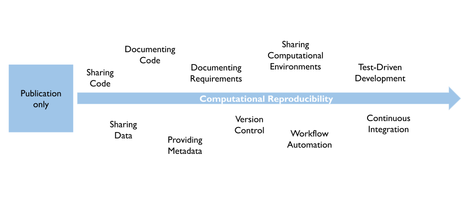

Molo, Fraga González, and Pawel (2025)

- Ziel heute: Verstehen, **was möglich ist** auf der rechten Seite
- ~~Ziel heute: Tiefes technisches Verständnis für fortgeschrittene Arbeitsabläufe ~~

## Dynamische Reports lösen copy-paste Probleme, aber…

- Wie behält man den Überblick über verschiedene **Dateiversionen**?
  - `Paper-final.qmd` → `Paper-final2.qmd` → `Paper-final2b.qmd` → 😱
  - Lösung: **Git**
- Woher weiß man, welche Dateien in welcher **Reihenfolge** ausgeführt werden sollen?
  - `functions.qmd`, `analysis.qmd`, `plots.qmd`, `paper.qmd`, 🤔
  - Lösung: **Make**
- Wie stellt man sicher, dass der Code noch läuft, wenn sich **Softwareversionen** ändern?
  - Heute”: R Version 4.5, ggplot2 3.5.2 → `Nächstes Jahr`: R Version ❓, ggplot2 ❓
  - Lösung: **Docker**
- Sehr schönes Paper über einen solchen Workflow: Peikert and Brandmaier (2021)

Molo, Fraga González, and Pawel (2025)

## Nützliche Tools 1: `renv`

- **R package** für **Reproduzierbarkeit** von R-Projekten

````markdown
```{r}
renv::init())  # renv initialisieren
renv::snapshot()  # Abhängigkeiten erfassen
renv::restore()  # Abhängigkeiten wiederherstellen
renv::dependencies()  # Abhängigkeiten auflisten
```
````

[figure not shown]

Landau (2021) & wlandau.github.io

## Versionskontrolle mit Git

- **De-facto-Standard** Versionskontrollsystem
- Kann **in der Zeit zurückgehen** zu früheren Versionen
- Kann **Änderungen** zwischen Versionen verfolgen
- Kann **verzweigen und zusammenführen**
- Nützlich für **Kollaboration** und **Dateitransfer**
- **Command-Line-Schnittstelle** (Lernkurve)
- **Grafische Schnittstelle** in vielen Editoren/IDEs (z. B. RStudio, VS Code)
- **Git** (Software) ≠ **GitHub**/GitLab (Git-Repository-Hosting-Dienste)
- Snapshots ermöglichen die **dauerhafte Archivierung** (mit DOI) auf Daten-Repositories (z. B. Zenodo)

[figure not shown]

https://git-scm.com/downloads/logos

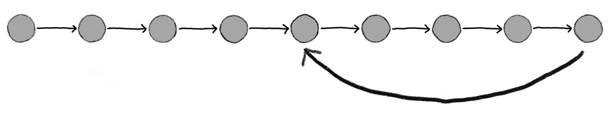

The Turing Way Community and Scriberia (2024)

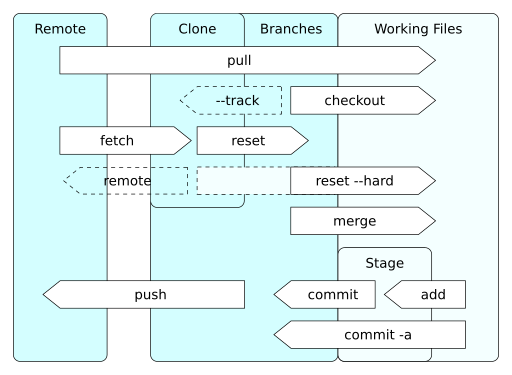

https://commons.wikimedia.org/wiki/File:Git_operations.svg

## Versionskontrolle mit Git - Wo starten?

- **Git installieren**
- **GitHub Account** erstellen
- **Git in RStudio** aktivieren
- **RStudio-Projekt** erstellen
- **RStudio-Projekt mit Git** initialisieren
- **RStudio-Projekt mit GitHub verbinden**

Gute Ressource: - Happy Git with R: https://happygitwithr.com/

## Automatisierung mit Make

- Tool für **komputationale Rezepte**
- Automatisierung von mehreren Schritten in einem

> Arrabbiata sauce, or sugo all’arrabbiata in Italian, is a spicy sauce for pasta made from garlic, tomatoes, and dried red chili peppers cooked in olive oil.

https://en.wikipedia.org/wiki/Arrabbiata_sauce

**Makefile**

```
arrabiata.pdf: arrabiata.qmd sauce.csv pasta.R
  quarto render arrabiata.qmd

sauce.csv: cook.R tomatoes.zip aromatics.yaml
  R -e "source(cook.R)"

aromatics.yaml: sizzle.py garlic.txt chili.json
  python sizzle.py garlic.txt
  python sizzle.py chili.json
```

**Terminal**

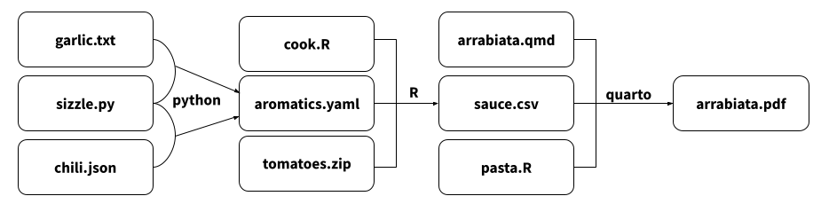

Molo, Fraga González, and Pawel (2025)

```bash
make arrabiata.pdf # execute recipe
```

## Containerisierung mit Docker

- **Software Container** beinhalten das komputationale Umfeld für die Ausführung von Code
- Komponenten eines Containers:
  - Operating System (OS)
  - R und R-Pakete (oder andere Programmiersprachen)
  - Numerische Bibliotheken (z.B., LAPACK, BLAS)
  - Andere Software (z.B., LaTeX, Java)
- **Docker** ist ein beliebtes Containerisierungstool
- **Rocker** ist ein Docker Image für R (https://rocker-project.org/)

Dockerfile

[figure not shown]

https://commons.wikimedia.org/wiki/File:Docker-svgrepo-com.svg

```
# Rocker container image mit R 4.4
FROM rocker/verse:4.4

# R Packages zum damaligen Zeitpunkt installieren
RUN install2.r ggplot2 dplyr kableExtra
```

## Alles zusammen

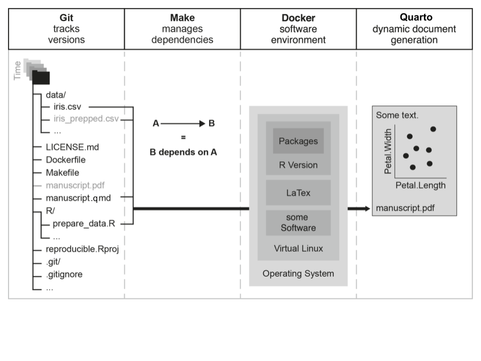

Nach Peikert and Brandmaier (2021) und Molo, Fraga González, and Pawel (2025)

Terminal

```bash
# alles in einem Schritt ausführen
make docker-report
```

→ `report.html`

## Abschlussdiskussion

- Welche Tools könnten am nützlichsten sein?
- Welche Tools sind am schwierigsten zu lernen?
- Wo sind die größten verbleibenden Hürden?

## Zusammenfassung

- Dynamische Reports + Versionskontrolle + Automatisierung + Containerisierung
  - verbessert **Reproduzierbarkeit**, **Wiederverwendbarkeit**, **Zusammenarbeit**
  - verleiht der Forschung mehr **Transparenz**, **Glaubwürdigkeit**
- Es gibt eine **Lernkurve** , aber …
  - beginnt einfach und lernen Sie **Schritt für Schritt** 💡.
  - die Tools werden **stetig weiterentwickelt** 🚀.
  - investierte Lernzeit kann Ihnen in Zukunft **Zeit sparen** ⏳
  - Fähigkeiten sind **innerhalb/außerhalb von Academia** nützlich 💰 👨‍🔬

[output not shown]

## Literatur

Landau, William Michael. 2021. “The Targets r Package: A Dynamic Make-Like Function-Oriented Pipeline Toolkit for Reproducibility and High-Performance Computing.” *Journal of Open Source Software* 6 (57): 2959. https://doi.org/10.21105/joss.02959.

Molo, Fabio, Gorka Fraga González, and Samuel Pawel. 2025. “Workshop ‘Reproducible and Dynamic Reporting with r and Quarto – Getting Started’ at UZH.” https://doi.org/doi.org/10.5281/zenodo.14169002.

Peikert, Aaron, and Andreas M. Brandmaier. 2021. “A Reproducible Data Analysis Workflow with r Markdown, Git, Make, and Docker.” *Quantitative and Computational Methods in Behavioral Sciences* 1. https://doi.org/10.5964/qcmb.3763.

The Turing Way Community, and Scriberia. 2024. “Illustrations from the Turing Way: Shared Under CC-BY 4.0 for Reuse.” Zenodo. https://doi.org/10.5281/ZENODO.3332807.

Ushey, Kevin, and Hadley Wickham. 2025. *Renv: Project Environments*. https://doi.org/10.32614/CRAN.package.renv.